# Regression Tree and Random Forest - US Crime

HP

2024-02-05

*Using crime data from the file uscrime.txt (http://www.statsci.org/data/general/uscrime.txt, description at [http://www.statsci.org/data/general/uscrime.html),](http://www.statsci.org/data/general/uscrime.html),)

The purpose of this portion is to find the best model using (a) a regression tree model, and (b) a random forest model.

```r
### Read in the data
crimedata <- read.table("data/uscrime.txt", stringsAsFactors = FALSE, header = TRUE)
```

### a) Regression Tree Model

#### Creating the Model

To create the regression tree model, I will use rpart. I then plot a visualization of the tree to get a general idea of the model.

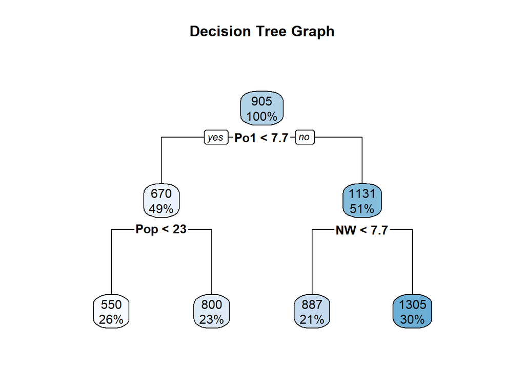

```r
set.seed(42)
## Use rpart to perform the regression model tree
crimeR <- rpart(
  formula = Crime ~ .,
  data    = crimedata,
  method  = "anova",
  )

## plot the tree
rpart.plot(crimeR, main="Decision Tree Graph")
```

```r
#crimeR
```

This graph gives us 4 leaves and uses three variables: PO1, Pop, and NW. The interpretation of the leaves are:

- When **Po1 < 7.7** and **Pop < 23**: The mean crime rate is **550**, and it covers **26%** of the data
- When **Po1 < 7.7** and **Pop > 23**: The mean crime rate is **800**, and it covers **23%** of the data
- When **Po1 > 7.7** and **NW < 7.7**: The mean crime rate is **887**, and it covers **21%** of the data
- When **Po1 > 7.7** and **NW > 7.7**: The mean crime rate is **1305**, and it covers **30%%** of the data

The table is a written summary of the decision tree graph.

Next is the **pruning table**, which gives more information regarding the accuracy of the data

```r
crimeR$cptable # output pruning table
```

```
##           CP nsplit rel error   xerror      xstd
## 1 0.36296293      0 1.0000000 1.044786 0.2605960
## 2 0.14814320      1 0.6370371 0.911051 0.1945477
## 3 0.05173165      2 0.4888939 1.012676 0.2303736
## 4 0.01000000      3 0.4371622 1.012402 0.2315240
```

The PruningTable depicts information about pruning from the rpart algorithm. There are two errors, **rel error** and **xerror**. rel error is the error for predictions within our model. **xerror is the cross-validation error** (rpart does cross validation for us). xerror is more useful in predicting the accuracy of this model.

In selecting the the level of our tree, the rule of thumb is to select the lowest level where **rel_error + xstd < xerror**. This would give us the 2nd level with an **xerror of 0.911.**

Last, we look at the **cost complexity** graph, which tells us how much error is gained or lost for each level of complexity.

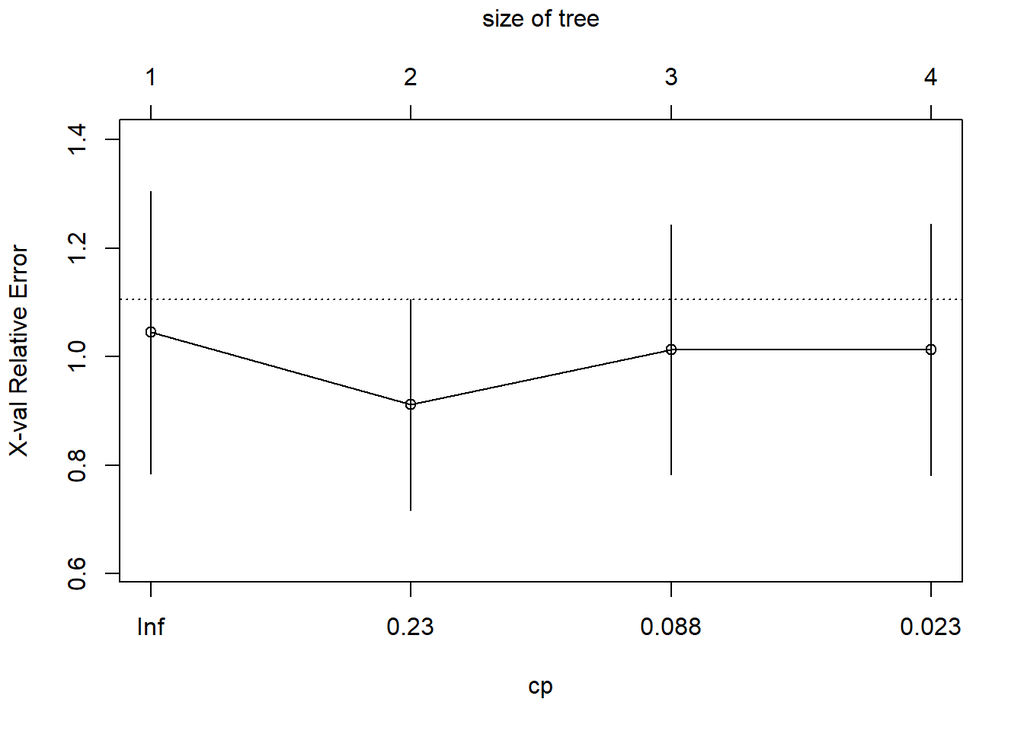

```r
plotcp(crimeR) # output cost complexity graph
```

This graph gives the same information of the pruning table: the model would be more **accurate with two levels instead of four**

#### Fitting the Model

The xerror is very high with this model, which means the accuracy is low. To attempt a more accurate model, the parameters in rpart allow for manipulation of the parameters.

minsplit: the minimum number of data points required to attempt a split before it is forced to create a terminal node. The model has very few splits, and I wanted to force a few more, so I changed minsplit to 8.

maxdepth: the maximum number of internal nodes between the root node and the terminal nodes. I set mine to 15.

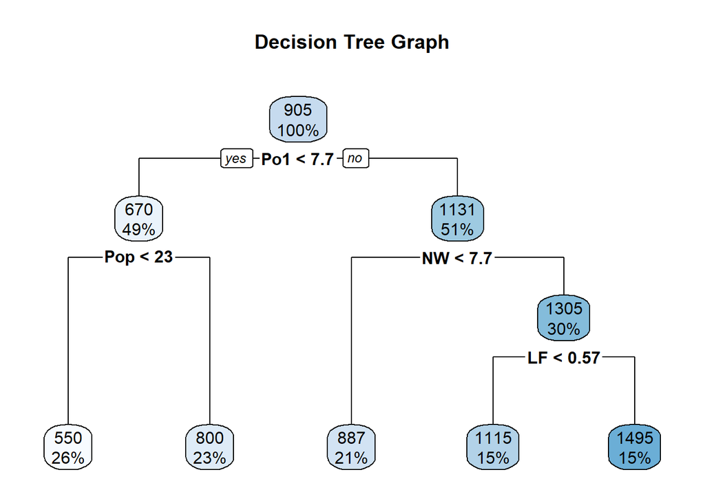

```r
## Use rpart to perform the regression model tree with added parameters
set.seed(13)
crimeA <- rpart(
  formula = Crime ~ .,
  data    = crimedata,
  method  = "anova",
  control = list(minsplit = 8, maxdepth = 15)
  )

## plot the tree
rpart.plot(crimeA, main="Decision Tree Graph")
```

The tree begins in the same way as our first tree. This one however, splits NW > 7.7 into another branch, LV <0.57. In this last leaf: when **LF < .057**: The mean crime rate is **1115**, and it covers **15%%** of the data when **LF > .057**: The mean crime rate is **1495**, and it covers **15%%** of the data

Now we look at the **pruning table** to see if the accuracy has changed.

```r
crimeA$cptable
```

```
##           CP nsplit rel error    xerror      xstd
## 1 0.36296293      0 1.0000000 1.0538157 0.2626902
## 2 0.14814320      1 0.6370371 1.0204770 0.2301254
## 3 0.07361517      2 0.4888939 0.9967139 0.2405021
## 4 0.05173165      3 0.4152787 0.9011645 0.2260895
## 5 0.01000000      4 0.3635470 0.8402136 0.2223336
```

The xerror values decrease as we add nodes in this table. However, if we follow the **rule of thumb**, then we still choose the second node, where **xerror = 1.02.** And we check it against the **complexity graph**

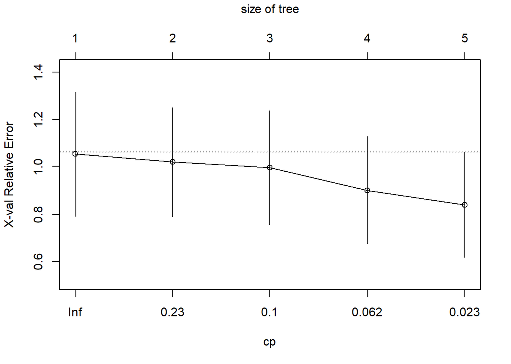

```r
plotcp(crimeA)
```

Here, the data shows a better relative error as the the nodes increase. However, these models can fall into over fitting with too many nodes, which is what I think is happening here.

**The best model is the default with two nodes**

### b) Random Forest Model

#### Creating the Model

To fit the data to a random forest model, I will use the randomForest package. First, create the model and output the data.

```r
CrimeF<- randomForest(Crime~., data = crimedata) #create model
CrimeF
```

```
##
## Call:
##  randomForest(formula = Crime ~ ., data = crimedata)
##                Type of random forest: regression
##                      Number of trees: 500
## No. of variables tried at each split: 5
##
##           Mean of squared residuals: 87173.98
##                     % Var explained: 40.46
```

This is further explained in the chart below

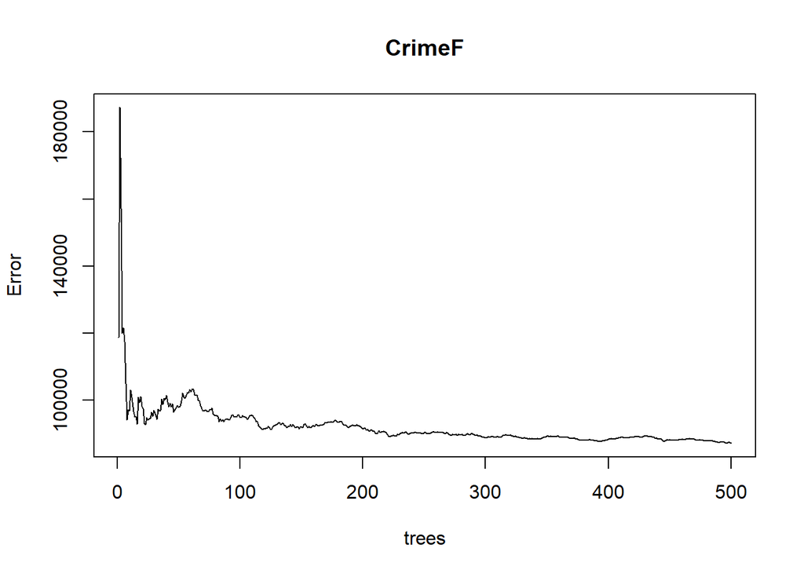

```r
plot(CrimeF)
```

#### Fitting the Model

As well as changing the number of trees from 500 to 250, I will change the split at each node from 5 to 4. I am doing this because the previous model suggested using a smaller amount of data

```r
CrimeFA<- randomForest(Crime~., data = crimedata, mtry = 4, ntree = 250)
CrimeFA
```

```
##
## Call:
##  randomForest(formula = Crime ~ ., data = crimedata, mtry = 4,      ntree = 250)
##                Type of random forest: regression
##                      Number of trees: 250
## No. of variables tried at each split: 4
##
##           Mean of squared residuals: 83283.13
##                     % Var explained: 43.11
```